# MTH 404 R Project

You Liang

2023-04-11

## DATA

We collected the data from ``kaggle datasets” named as “KC_Housesales_Data”. The link of the data: https://www.kaggle.com/swathiachath/kc-housesales-data

Online property companies offer valuations of houses using machine learning techniques. The aim of this report is to predict the house sales in King County, Washington State, USA using Multiple Linear Regression (MLR). The dataset consisted of historic data of houses sold between May 2014 to May 2015.

```r
library(tidyverse)
```

```r
library(corrplot)
library(lubridate)
library(readr)
library(caTools)
library(GGally)
library(caret)
library(leaps)
```

```r
mydata = read_csv("kc_house_data.csv")
head(mydata)
```

```
## # A tibble: 6 × 21
##           id date     price bedro…¹ bathr…² sqft_…³ sqft_…⁴ floors water…⁵  view
##        <dbl> <chr>    <dbl>   <dbl>   <dbl>   <dbl>   <dbl>  <dbl>   <dbl> <dbl>
## 1 7129300520 10/13/… 2.22e5       3    1       1180    5650      1       0     0
## 2 6414100192 12/9/2… 5.38e5       3    2.25    2570    7242      2       0     0
## 3 5631500400 2/25/2… 1.8 e5       2    1        770   10000      1       0     0
## 4 2487200875 12/9/2… 6.04e5       4    3       1960    5000      1       0     0
## 5 1954400510 2/18/2… 5.1 e5       3    2       1680    8080      1       0     0
## 6 7237550310 5/12/2… 1.23e6       4    4.5     5420  101930      1       0     0
## # … with 11 more variables: condition <dbl>, grade <dbl>, sqft_above <dbl>,
## #   sqft_basement <dbl>, yr_built <dbl>, yr_renovated <dbl>, zipcode <dbl>,
## #   lat <dbl>, long <dbl>, sqft_living15 <dbl>, sqft_lot15 <dbl>, and
## #   abbreviated variable names ¹bedrooms, ²bathrooms, ³sqft_living, ⁴sqft_lot,
## #   ⁵waterfront
```

```r
str(mydata)
```

```
## spc_tbl_ [21,597 × 21] (S3: spec_tbl_df/tbl_df/tbl/data.frame)
##  $ id           : num [1:21597] 7.13e+09 6.41e+09 5.63e+09 2.49e+09 1.95e+09 ...
##  $ date         : chr [1:21597] "10/13/2014" "12/9/2014" "2/25/2015" "12/9/2014" ...
##  $ price        : num [1:21597] 221900 538000 180000 604000 510000 ...
##  $ bedrooms     : num [1:21597] 3 3 2 4 3 4 3 3 3 3 ...
##  $ bathrooms    : num [1:21597] 1 2.25 1 3 2 4.5 2.25 1.5 1 2.5 ...
##  $ sqft_living  : num [1:21597] 1180 2570 770 1960 1680 ...
##  $ sqft_lot     : num [1:21597] 5650 7242 10000 5000 8080 ...
##  $ floors       : num [1:21597] 1 2 1 1 1 1 2 1 1 2 ...
##  $ waterfront   : num [1:21597] 0 0 0 0 0 0 0 0 0 0 ...
##  $ view         : num [1:21597] 0 0 0 0 0 0 0 0 0 0 ...
##  $ condition    : num [1:21597] 3 3 3 5 3 3 3 3 3 3 ...
##  $ grade        : num [1:21597] 7 7 6 7 8 11 7 7 7 7 ...
##  $ sqft_above   : num [1:21597] 1180 2170 770 1050 1680 ...
##  $ sqft_basement: num [1:21597] 0 400 0 910 0 1530 0 0 730 0 ...
##  $ yr_built     : num [1:21597] 1955 1951 1933 1965 1987 ...
##  $ yr_renovated : num [1:21597] 0 1991 0 0 0 ...
##  $ zipcode      : num [1:21597] 98178 98125 98028 98136 98074 ...
##  $ lat          : num [1:21597] 47.5 47.7 47.7 47.5 47.6 ...
##  $ long         : num [1:21597] -122 -122 -122 -122 -122 ...
##  $ sqft_living15: num [1:21597] 1340 1690 2720 1360 1800 ...
##  $ sqft_lot15   : num [1:21597] 5650 7639 8062 5000 7503 ...
##  - attr(*, "spec")=
##   .. cols(
##   ..   id = col_double(),
##   ..   date = col_character(),
##   ..   price = col_double(),
##   ..   bedrooms = col_double(),
##   ..   bathrooms = col_double(),
##   ..   sqft_living = col_double(),
##   ..   sqft_lot = col_double(),
##   ..   floors = col_double(),
##   ..   waterfront = col_double(),
##   ..   view = col_double(),
##   ..   condition = col_double(),
##   ..   grade = col_double(),
##   ..   sqft_above = col_double(),
##   ..   sqft_basement = col_double(),
##   ..   yr_built = col_double(),
##   ..   yr_renovated = col_double(),
##   ..   zipcode = col_double(),
##   ..   lat = col_double(),
##   ..   long = col_double(),
##   ..   sqft_living15 = col_double(),
##   ..   sqft_lot15 = col_double()
##   .. )
##  - attr(*, "problems")=<externalptr>
```

```r
summary(mydata)
```

```
##        id                date               price            bedrooms
##  Min.   :1.000e+06   Length:21597       Min.   :  78000   Min.   : 1.000
##  1st Qu.:2.123e+09   Class :character   1st Qu.: 322000   1st Qu.: 3.000
##  Median :3.905e+09   Mode  :character   Median : 450000   Median : 3.000
##  Mean   :4.580e+09                      Mean   : 540297   Mean   : 3.373
##  3rd Qu.:7.309e+09                      3rd Qu.: 645000   3rd Qu.: 4.000
##  Max.   :9.900e+09                      Max.   :7700000   Max.   :33.000
##    bathrooms      sqft_living       sqft_lot           floors
##  Min.   :0.500   Min.   :  370   Min.   :    520   Min.   :1.000
##  1st Qu.:1.750   1st Qu.: 1430   1st Qu.:   5040   1st Qu.:1.000
##  Median :2.250   Median : 1910   Median :   7618   Median :1.500
##  Mean   :2.116   Mean   : 2080   Mean   :  15099   Mean   :1.494
##  3rd Qu.:2.500   3rd Qu.: 2550   3rd Qu.:  10685   3rd Qu.:2.000
##  Max.   :8.000   Max.   :13540   Max.   :1651359   Max.   :3.500
##    waterfront            view          condition        grade
##  Min.   :0.000000   Min.   :0.0000   Min.   :1.00   Min.   : 3.000
##  1st Qu.:0.000000   1st Qu.:0.0000   1st Qu.:3.00   1st Qu.: 7.000
##  Median :0.000000   Median :0.0000   Median :3.00   Median : 7.000
##  Mean   :0.007547   Mean   :0.2343   Mean   :3.41   Mean   : 7.658
##  3rd Qu.:0.000000   3rd Qu.:0.0000   3rd Qu.:4.00   3rd Qu.: 8.000
##  Max.   :1.000000   Max.   :4.0000   Max.   :5.00   Max.   :13.000
##    sqft_above   sqft_basement       yr_built     yr_renovated
##  Min.   : 370   Min.   :   0.0   Min.   :1900   Min.   :   0.00
##  1st Qu.:1190   1st Qu.:   0.0   1st Qu.:1951   1st Qu.:   0.00
##  Median :1560   Median :   0.0   Median :1975   Median :   0.00
##  Mean   :1789   Mean   : 291.7   Mean   :1971   Mean   :  84.46
##  3rd Qu.:2210   3rd Qu.: 560.0   3rd Qu.:1997   3rd Qu.:   0.00
##  Max.   :9410   Max.   :4820.0   Max.   :2015   Max.   :2015.00
##     zipcode           lat             long        sqft_living15
##  Min.   :98001   Min.   :47.16   Min.   :-122.5   Min.   : 399
##  1st Qu.:98033   1st Qu.:47.47   1st Qu.:-122.3   1st Qu.:1490
##  Median :98065   Median :47.57   Median :-122.2   Median :1840
##  Mean   :98078   Mean   :47.56   Mean   :-122.2   Mean   :1987
##  3rd Qu.:98118   3rd Qu.:47.68   3rd Qu.:-122.1   3rd Qu.:2360
##  Max.   :98199   Max.   :47.78   Max.   :-121.3   Max.   :6210
##    sqft_lot15
##  Min.   :   651
##  1st Qu.:  5100
##  Median :  7620
##  Mean   : 12758
##  3rd Qu.: 10083
##  Max.   :871200
```

```r
NA_values=data.frame(no_of_na_values=colSums(is.na(mydata)))
head(NA_values,21)
```

```
##               no_of_na_values
## id                          0
## date                        0
## price                       0
## bedrooms                    0
## bathrooms                   0
## sqft_living                 0
## sqft_lot                    0
## floors                      0
## waterfront                  0
## view                        0
## condition                   0
## grade                       0
## sqft_above                  0
## sqft_basement               0
## yr_built                    0
## yr_renovated                0
## zipcode                     0
## lat                         0
## long                        0
## sqft_living15               0
## sqft_lot15                  0
```

We see that there are no missing values in this data.

## EXPLORATORY DATA ANALYSIS ON THE TRAIN DATA

```r
date_sale=mdy(mydata$date)
mydata$sale_date_year=as.integer(year(date_sale))
mydata$age=mydata$sale_date_year-mydata$yr_built

mydata$reno=ifelse(mydata$yr_renovated==0,0,1)
mydata$reno=as.factor(mydata$reno)
```

### Training and test data

Set seed to be your student number. We divide the data to be the training set (80%) and test set (20%).

```r
set.seed(123)   #  set seed to be your student number
n <- nrow(mydata)
ntest <- trunc(0.2*n)
testid <- sample (1:n, ntest)
train_data <- mydata[-testid , ]
test_data <- mydata[testid , ]
```

### Check the response variable

The price is skewed to the right with several very high prices.

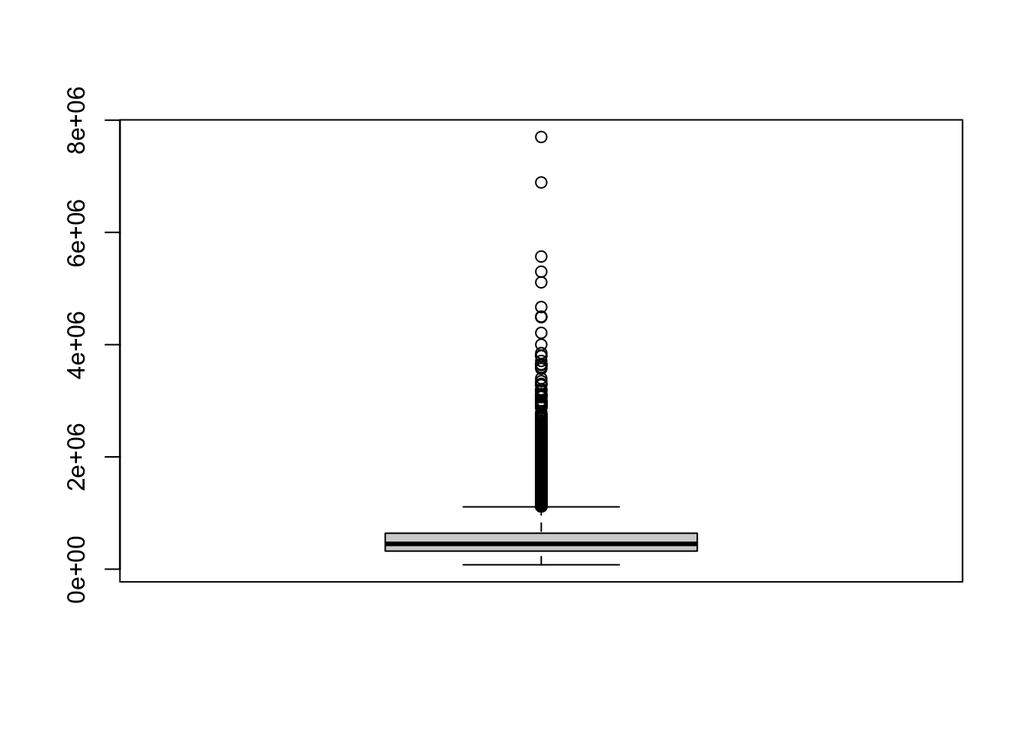

```r
boxplot(train_data$price)
```

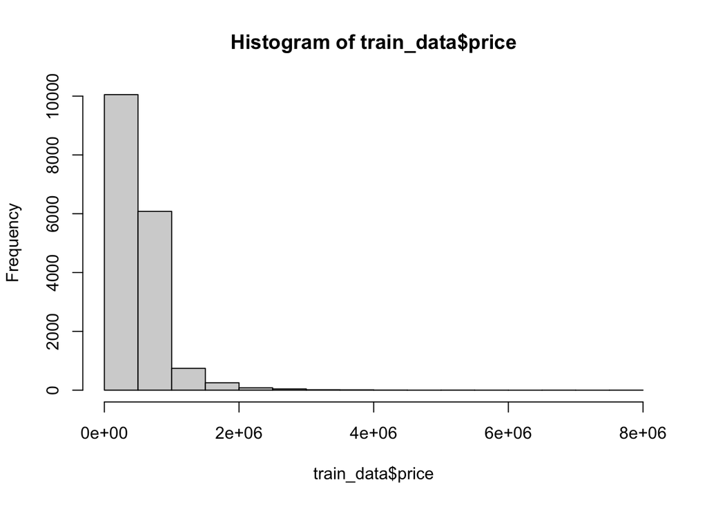

```r
hist (train_data$price)
```

### Determining the association between variables.

We take out the correlation plot (corrplot) to understand the association of the dependent variable (price) with the independent variables.

```r
cor_data=data.frame(train_data[,3:21])
correlation=cor(cor_data)
correlation
```

```
##                     price     bedrooms   bathrooms sqft_living     sqft_lot
## price          1.00000000  0.306302787  0.52490594  0.70212024  0.084347903
## bedrooms       0.30630279  1.000000000  0.51055538  0.57297715  0.027650923
## bathrooms      0.52490594  0.510555381  1.00000000  0.75228007  0.078103071
## sqft_living    0.70212024  0.572977152  0.75228007  1.00000000  0.164906173
## sqft_lot       0.08434790  0.027650923  0.07810307  0.16490617  1.000000000
## floors         0.25927538  0.176161143  0.50595510  0.35375593 -0.009305346
## waterfront     0.26663606 -0.004203099  0.06734178  0.10573791  0.015507153
## view           0.39696983  0.075091326  0.18287640  0.28006469  0.064215017
## condition      0.04048509  0.033251516 -0.12226088 -0.05312872 -0.007590424
## grade          0.66792578  0.349968608  0.66195085  0.76301647  0.105263034
## sqft_above     0.60303192  0.472491302  0.68450153  0.87558637  0.176088535
## sqft_basement  0.32656512  0.303097464  0.27829769  0.43394077  0.012438925
## yr_built       0.05344571  0.151088523  0.50561628  0.31695206  0.046040871
## yr_renovated   0.12164813  0.022015283  0.05298045  0.05732197  0.011144552
## zipcode       -0.04374666 -0.151558128 -0.19896966 -0.19508520 -0.127713005
## lat            0.30873338 -0.008250136  0.02226417  0.05095703 -0.077745920
## long           0.01728054  0.127670792  0.21866126  0.23541131  0.221027374
## sqft_living15  0.58219439  0.389774460  0.56319978  0.75614768  0.144348312
## sqft_lot15     0.07999305  0.027023608  0.08123401  0.17995276  0.723738906
##                     floors   waterfront         view    condition       grade
## price          0.259275382  0.266636063  0.396969830  0.040485087  0.66792578
## bedrooms       0.176161143 -0.004203099  0.075091326  0.033251516  0.34996861
## bathrooms      0.505955100  0.067341777  0.182876397 -0.122260876  0.66195085
## sqft_living    0.353755928  0.105737911  0.280064688 -0.053128717  0.76301647
## sqft_lot      -0.009305346  0.015507153  0.064215017 -0.007590424  0.10526303
## floors         1.000000000  0.027303391  0.025500557 -0.261858784  0.46109093
## waterfront     0.027303391  1.000000000  0.402380080  0.018982642  0.08353448
## view           0.025500557  0.402380080  1.000000000  0.047676331  0.24901143
## condition     -0.261858784  0.018982642  0.047676331  1.000000000 -0.14467247
## grade          0.461090934  0.083534480  0.249011425 -0.144672472  1.00000000
## sqft_above     0.524749062  0.073949968  0.161674571 -0.153976780  0.75612677
## sqft_basement -0.247489596  0.080635204  0.277350701  0.177361466  0.16690372
## yr_built       0.490071230 -0.020644085 -0.053508083 -0.359024804  0.44646652
## yr_renovated   0.010800710  0.082118838  0.101567236 -0.060711155  0.01807452
## zipcode       -0.055487353  0.032590023  0.088109529  0.001374973 -0.17871974
## lat            0.049293971 -0.015880113  0.005464341 -0.016686007  0.11233900
## long           0.122612845 -0.040056713 -0.078155059 -0.105145980  0.19486912
## sqft_living15  0.280676336  0.082875200  0.273640870 -0.090018490  0.71035915
## sqft_lot15    -0.009790261  0.033659660  0.067732862 -0.002310117  0.11475100
```

[output cut: 25 more lines]

```
## sqft_lot      -0.077745920  0.22102737   0.144348312  0.723738906
## floors         0.049293971  0.12261284   0.280676336 -0.009790261
## waterfront    -0.015880113 -0.04005671   0.082875200  0.033659660
## view           0.005464341 -0.07815506   0.273640870  0.067732862
## condition     -0.016686007 -0.10514598  -0.090018490 -0.002310117
## grade          0.112339001  0.19486912   0.710359154  0.114750998
## sqft_above    -0.001088706  0.33788298   0.731947188  0.189917516
## sqft_basement  0.107356972 -0.14358651   0.197802645  0.017747769
## yr_built      -0.148227566  0.40938151   0.323045128  0.067202845
## yr_renovated   0.025793897 -0.07182978   0.000108915  0.014171453
## zipcode        0.268750571 -0.56607531  -0.277278790 -0.145160008
## lat            1.000000000 -0.13316643   0.050721208 -0.080010083
## long          -0.133166426  1.00000000   0.332957537  0.248039625
## sqft_living15  0.050721208  0.33295754   1.000000000  0.180965468
## sqft_lot15    -0.080010083  0.24803963   0.180965468  1.000000000
```

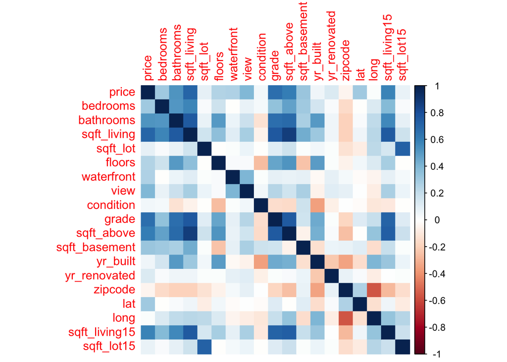

```r
par(mfrow=c(1, 1))
corrplot(correlation,method="color")
```

Price is strongly positively correlated with bathroom, Sqft_living, grade, sqft_above, sqft_living15. We use scatterplot and boxplot to visualize the relationship between price and some predictors.

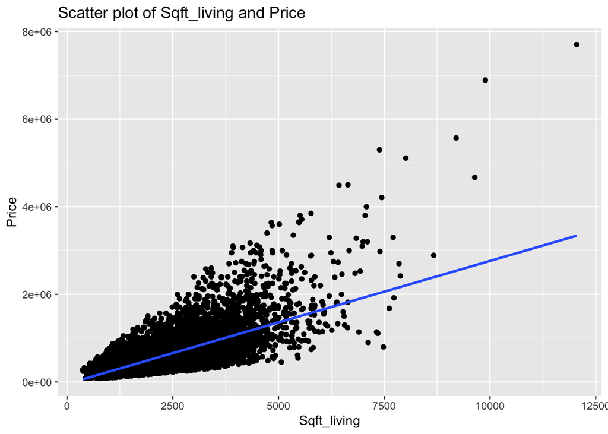

```r
ggplot(data = train_data, aes(x = sqft_living, y = price)) +
  geom_jitter() +  geom_smooth(method = "lm", se = FALSE)+labs(title="Scatter plot of Sqft_living and Price", x="Sqft_living",y="Price")
```

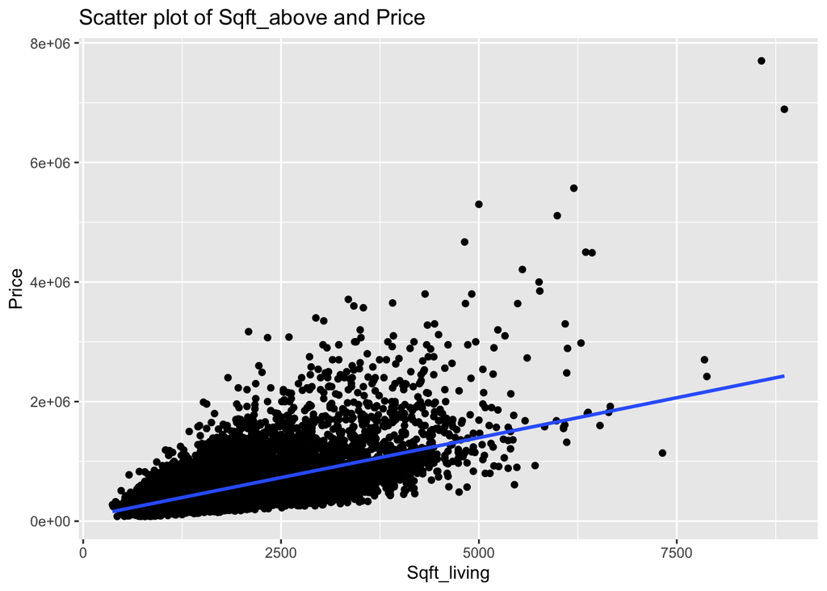

```r
ggplot(data = train_data, aes(x = sqft_above, y = price)) +
  geom_jitter() +  geom_smooth(method = "lm", se = FALSE)+labs(title="Scatter plot of Sqft_above and Price", x="Sqft_living",y="Price")
```

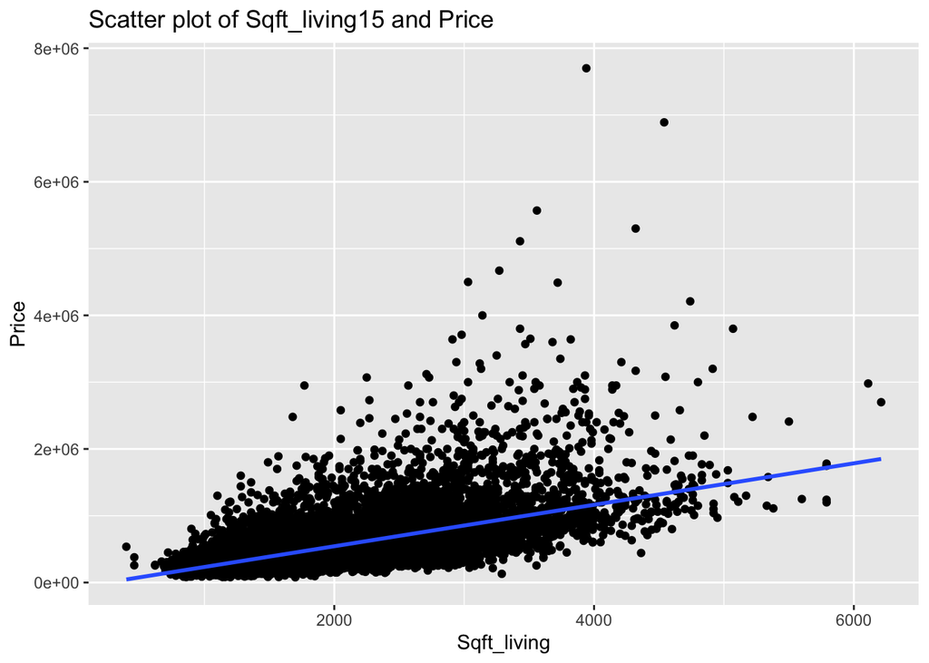

```r
ggplot(data = train_data, aes(x = sqft_living15, y = price)) +
  geom_jitter() +  geom_smooth(method = "lm", se = FALSE)+labs(title="Scatter plot of Sqft_living15 and Price", x="Sqft_living",y="Price")
```

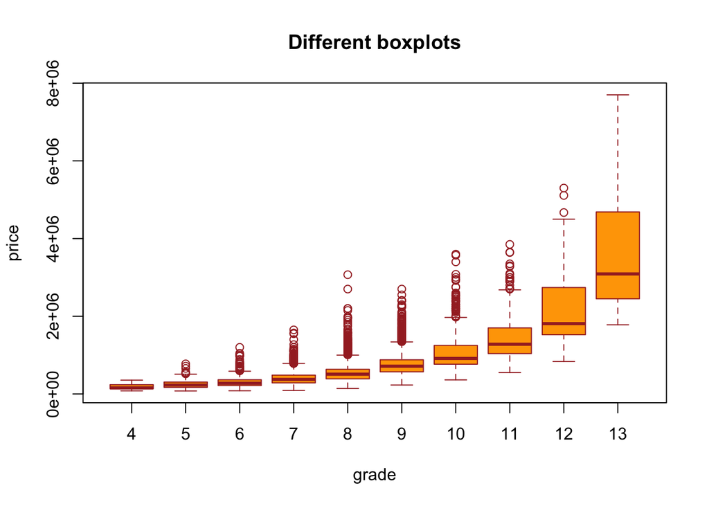

```r
boxplot(price~grade,data=train_data,main="Different boxplots", xlab="grade",ylab="price",col="orange",border="brown")
```

Check the new added variables:

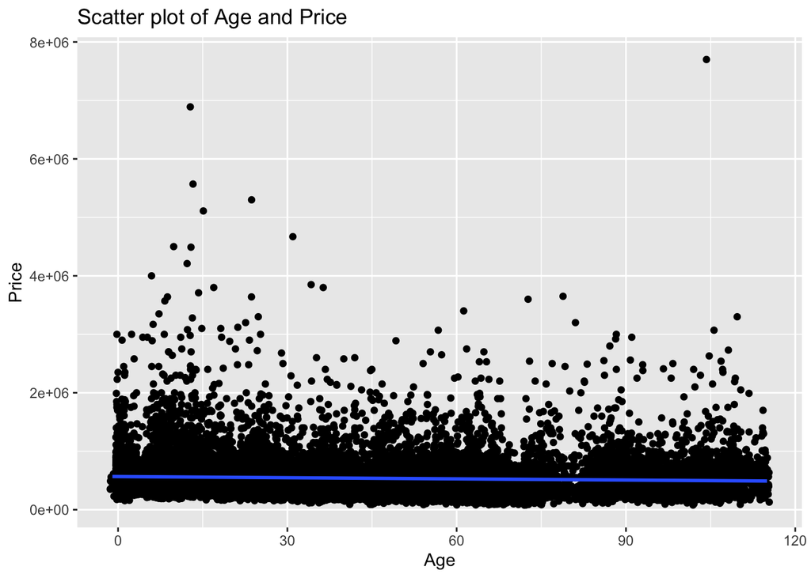

```r
ggplot(data = train_data, aes(x = age, y = price)) +
  geom_jitter() +  geom_smooth(method = "lm", se = FALSE)+labs(title="Scatter plot of Age and Price", x="Age",y="Price")
```

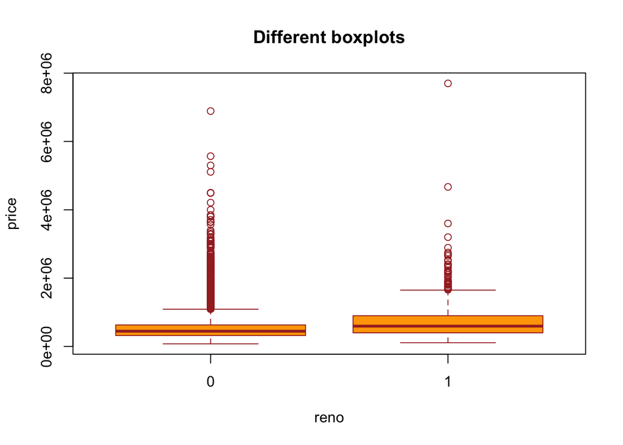

```r
boxplot(price~reno,data=train_data,main="Different boxplots", xlab="reno",ylab="price",col="orange",border="brown")
```

### Removing outlier could be optional

We see that we have a significantly large number of outliers.

Treating or altering the outlier/extreme values in genuine observations is not a standard operating procedure. However, it is essential to understand their impact on our predictive models.

To better understand the implications of outliers better, we should compare the fit of a simple linear regression model on the dataset with and without outliers. For this we first extract outliers from the data and then obtain the data without the outliers.

```r
outliers=boxplot(train_data$price,plot=FALSE)$out
outliers_data=train_data[which(train_data$price %in% outliers),]
train_data1= train_data[-which(train_data$price %in% outliers),]
```

Now plot Now we plot the data with and without outliers.

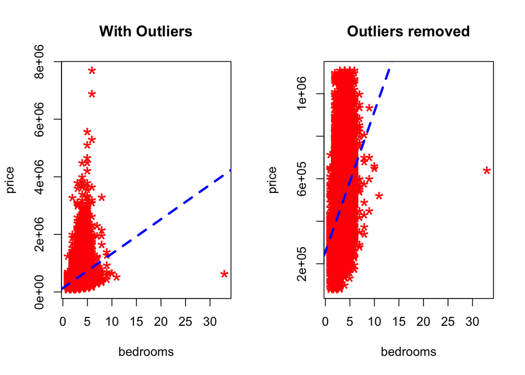

```r
par(mfrow=c(1, 2))
plot(train_data$bedrooms, train_data$price, main="With Outliers", xlab="bedrooms", ylab="price", pch="*", col="red", cex=2)
abline(lm(price ~ bedrooms, data=train_data), col="blue", lwd=3, lty=2)
# Plot of original data without outliers. Note the change of slope.
plot(train_data1$bedrooms, train_data1$price, main="Outliers removed", xlab="bedrooms", ylab="price", pch="*", col="red", cex=2)
abline(lm(price ~bedrooms, data=train_data1), col="blue", lwd=3, lty=2)
```

## MODELING

```r
head(outliers_data)
```

```
## # A tibble: 6 × 24
##           id date     price bedro…¹ bathr…² sqft_…³ sqft_…⁴ floors water…⁵  view
##        <dbl> <chr>    <dbl>   <dbl>   <dbl>   <dbl>   <dbl>  <dbl>   <dbl> <dbl>
## 1 7237550310 5/12/2… 1.23e6       4    4.5     5420  101930      1       0     0
## 2 2524049179 8/26/2… 2   e6       3    2.75    3050   44867      1       0     4
## 3  822039084 3/11/2… 1.35e6       3    2.5     2753   65005      1       1     2
## 4 1802000060 6/12/2… 1.33e6       5    2.25    3200   20158      1       0     0
## 5 7855801670 4/1/20… 2.25e6       4    3.25    5180   19850      2       0     3
## 6   46100204 2/21/2… 1.51e6       5    3       3300   33474      1       0     3
## # … with 14 more variables: condition <dbl>, grade <dbl>, sqft_above <dbl>,
## #   sqft_basement <dbl>, yr_built <dbl>, yr_renovated <dbl>, zipcode <dbl>,
## #   lat <dbl>, long <dbl>, sqft_living15 <dbl>, sqft_lot15 <dbl>,
## #   sale_date_year <int>, age <dbl>, reno <fct>, and abbreviated variable names
## #   ¹bedrooms, ²bathrooms, ³sqft_living, ⁴sqft_lot, ⁵waterfront
```

```r
str(outliers_data)
```

```
## tibble [919 × 24] (S3: tbl_df/tbl/data.frame)
##  $ id            : num [1:919] 7.24e+09 2.52e+09 8.22e+08 1.80e+09 7.86e+09 ...
##  $ date          : chr [1:919] "5/12/2014" "8/26/2014" "3/11/2015" "6/12/2014" ...
##  $ price         : num [1:919] 1230000 2000000 1350000 1330000 2250000 1510000 2400000 1370000 2050000 3080000 ...
##  $ bedrooms      : num [1:919] 4 3 3 5 4 5 4 4 5 4 ...
##  $ bathrooms     : num [1:919] 4.5 2.75 2.5 2.25 3.25 3 2.5 4.75 3 5 ...
##  $ sqft_living   : num [1:919] 5420 3050 2753 3200 5180 ...
##  $ sqft_lot      : num [1:919] 101930 44867 65005 20158 19850 ...
##  $ floors        : num [1:919] 1 1 1 1 2 1 1 2 2 1 ...
##  $ waterfront    : num [1:919] 0 0 1 0 0 0 1 0 0 1 ...
##  $ view          : num [1:919] 0 4 2 0 3 3 4 0 1 4 ...
##  $ condition     : num [1:919] 3 3 5 3 3 3 3 4 5 3 ...
##  $ grade         : num [1:919] 11 9 9 8 12 9 9 11 9 10 ...
##  $ sqft_above    : num [1:919] 3890 2330 2165 1600 3540 ...
##  $ sqft_basement : num [1:919] 1530 720 588 1600 1640 1430 1820 0 1200 1950 ...
##  $ yr_built      : num [1:919] 2001 1968 1953 1965 2006 ...
##  $ yr_renovated  : num [1:919] 0 0 0 0 0 ...
##  $ zipcode       : num [1:919] 98053 98040 98070 98004 98006 ...
##  $ lat           : num [1:919] 47.7 47.5 47.4 47.6 47.6 ...
##  $ long          : num [1:919] -122 -122 -122 -122 -122 ...
##  $ sqft_living15 : num [1:919] 4760 4110 2680 3390 3160 ...
##  $ sqft_lot15    : num [1:919] 101930 20336 72513 20158 9750 ...
##  $ sale_date_year: int [1:919] 2014 2014 2015 2014 2015 2015 2014 2014 2015 2014 ...
##  $ age           : num [1:919] 13 46 62 49 9 58 14 25 110 12 ...
##  $ reno          : Factor w/ 2 levels "0","1": 1 1 1 1 1 2 1 1 2 1 ...
```

```r
outliers_data.m <- outliers_data[, -c(1, 2, 15, 16, 17, 22)] %>% mutate(waterfront=as.factor(waterfront), view=as.factor(view), condition=as.factor(condition), reno = as.factor(reno))
str (outliers_data.m)
```

```
## tibble [919 × 18] (S3: tbl_df/tbl/data.frame)
##  $ price        : num [1:919] 1230000 2000000 1350000 1330000 2250000 1510000 2400000 1370000 2050000 3080000 ...
##  $ bedrooms     : num [1:919] 4 3 3 5 4 5 4 4 5 4 ...
##  $ bathrooms    : num [1:919] 4.5 2.75 2.5 2.25 3.25 3 2.5 4.75 3 5 ...
##  $ sqft_living  : num [1:919] 5420 3050 2753 3200 5180 ...
##  $ sqft_lot     : num [1:919] 101930 44867 65005 20158 19850 ...
##  $ floors       : num [1:919] 1 1 1 1 2 1 1 2 2 1 ...
##  $ waterfront   : Factor w/ 2 levels "0","1": 1 1 2 1 1 1 2 1 1 2 ...
##  $ view         : Factor w/ 5 levels "0","1","2","3",..: 1 5 3 1 4 4 5 1 2 5 ...
##  $ condition    : Factor w/ 5 levels "1","2","3","4",..: 3 3 5 3 3 3 3 4 5 3 ...
##  $ grade        : num [1:919] 11 9 9 8 12 9 9 11 9 10 ...
##  $ sqft_above   : num [1:919] 3890 2330 2165 1600 3540 ...
##  $ sqft_basement: num [1:919] 1530 720 588 1600 1640 1430 1820 0 1200 1950 ...
##  $ lat          : num [1:919] 47.7 47.5 47.4 47.6 47.6 ...
##  $ long         : num [1:919] -122 -122 -122 -122 -122 ...
##  $ sqft_living15: num [1:919] 4760 4110 2680 3390 3160 ...
##  $ sqft_lot15   : num [1:919] 101930 20336 72513 20158 9750 ...
##  $ age          : num [1:919] 13 46 62 49 9 58 14 25 110 12 ...
##  $ reno         : Factor w/ 2 levels "0","1": 1 1 1 1 1 2 1 1 2 1 ...
```

```r
ncol(outliers_data.m)
```

```
## [1] 18
```

```r
model.full <- lm (formula = price ~ ., data = outliers_data.m)
summary(model.full)
```

```
##
## Call:
## lm(formula = price ~ ., data = outliers_data.m)
##
## Residuals:
##      Min       1Q   Median       3Q      Max
## -1390152  -256300   -36404   221466  2817661
##
## Coefficients: (1 not defined because of singularities)
##                 Estimate Std. Error t value Pr(>|t|)
## (Intercept)   -2.301e+08  2.594e+07  -8.867  < 2e-16 ***
## bedrooms      -3.268e+04  1.896e+04  -1.724 0.085078 .
## bathrooms      1.190e+05  2.632e+04   4.524 6.90e-06 ***
## sqft_living    1.963e+02  2.763e+01   7.107 2.43e-12 ***
## sqft_lot      -7.123e-02  4.848e-01  -0.147 0.883223
## floors        -1.424e+05  3.620e+04  -3.933 9.05e-05 ***
## waterfront1    6.674e+05  7.168e+04   9.311  < 2e-16 ***
## view1          1.411e+05  7.416e+04   1.903 0.057394 .
## view2         -1.586e+04  4.600e+04  -0.345 0.730296
## view3          2.355e+04  4.678e+04   0.503 0.614875
## view4          8.582e+04  5.978e+04   1.435 0.151512
## condition2    -5.939e+05  5.432e+05  -1.093 0.274530
## condition3    -6.663e+05  4.442e+05  -1.500 0.134001
## condition4    -5.679e+05  4.441e+05  -1.279 0.201285
## condition5    -5.992e+05  4.454e+05  -1.345 0.178882
## grade          7.410e+04  1.896e+04   3.908 0.000100 ***
## sqft_above     1.202e+02  2.907e+01   4.135 3.88e-05 ***
## sqft_basement         NA         NA      NA       NA
## lat            1.017e+06  2.648e+05   3.839 0.000132 ***
## long          -1.488e+06  2.007e+05  -7.411 2.90e-13 ***
## sqft_living15  2.899e+01  2.310e+01   1.255 0.209651
## sqft_lot15    -7.408e-01  6.755e-01  -1.097 0.273059
## age            1.803e+03  6.694e+02   2.694 0.007194 **
## reno1          4.003e+04  5.082e+04   0.788 0.431045
## ---
## Signif. codes:  0 '***' 0.001 '**' 0.01 '*' 0.05 '.' 0.1 ' ' 1
##
## Residual standard error: 441300 on 896 degrees of freedom
## Multiple R-squared:  0.5427, Adjusted R-squared:  0.5314
## F-statistic: 48.33 on 22 and 896 DF,  p-value: < 2.2e-16
```

```r
models <- regsubsets(price~., data = outliers_data.m, nvmax = 23)
```

```
## Reordering variables and trying again:
```

```r
summary(models)
```

```
## Subset selection object
## Call: regsubsets.formula(price ~ ., data = outliers_data.m, nvmax = 23)
## 23 Variables  (and intercept)
##               Forced in Forced out
## bedrooms          FALSE      FALSE
## bathrooms         FALSE      FALSE
## sqft_living       FALSE      FALSE
## sqft_lot          FALSE      FALSE
## floors            FALSE      FALSE
## waterfront1       FALSE      FALSE
## view1             FALSE      FALSE
## view2             FALSE      FALSE
## view3             FALSE      FALSE
## view4             FALSE      FALSE
## condition2        FALSE      FALSE
## condition3        FALSE      FALSE
## condition4        FALSE      FALSE
## condition5        FALSE      FALSE
## grade             FALSE      FALSE
## sqft_above        FALSE      FALSE
## lat               FALSE      FALSE
## long              FALSE      FALSE
## sqft_living15     FALSE      FALSE
## sqft_lot15        FALSE      FALSE
## age               FALSE      FALSE
## reno1             FALSE      FALSE
## sqft_basement     FALSE      FALSE
## 1 subsets of each size up to 22
## Selection Algorithm: exhaustive
##           bedrooms bathrooms sqft_living sqft_lot floors waterfront1 view1
## 1  ( 1 )  " "      " "       "*"         " "      " "    " "         " "
## 2  ( 1 )  " "      " "       "*"         " "      " "    "*"         " "
## 3  ( 1 )  " "      " "       "*"         " "      " "    "*"         " "
## 4  ( 1 )  " "      " "       "*"         " "      " "    "*"         " "
## 5  ( 1 )  " "      " "       "*"         " "      " "    "*"         " "
## 6  ( 1 )  " "      " "       "*"         " "      " "    "*"         " "
## 7  ( 1 )  " "      "*"       "*"         " "      " "    "*"         " "
## 8  ( 1 )  " "      "*"       "*"         " "      "*"    "*"         " "
## 9  ( 1 )  " "      "*"       " "         " "      "*"    "*"         " "
## 10  ( 1 ) " "      "*"       "*"         " "      "*"    "*"         " "
```

[output cut: 43 more lines]

```
## 8  ( 1 )  " "        "*"           " " "*"  " "           " "        "*" " "
## 9  ( 1 )  "*"        "*"           "*" "*"  " "           " "        "*" " "
## 10  ( 1 ) "*"        " "           "*" "*"  " "           " "        "*" " "
## 11  ( 1 ) "*"        " "           "*" "*"  " "           " "        "*" " "
## 12  ( 1 ) "*"        " "           "*" "*"  " "           "*"        "*" " "
## 13  ( 1 ) "*"        "*"           "*" "*"  " "           "*"        "*" " "
## 14  ( 1 ) "*"        "*"           "*" "*"  " "           "*"        "*" " "
## 15  ( 1 ) "*"        "*"           "*" "*"  "*"           "*"        "*" " "
## 16  ( 1 ) "*"        "*"           "*" "*"  "*"           "*"        "*" "*"
## 17  ( 1 ) " "        "*"           "*" "*"  "*"           "*"        "*" "*"
## 18  ( 1 ) " "        "*"           "*" "*"  "*"           "*"        "*" " "
## 19  ( 1 ) "*"        "*"           "*" "*"  "*"           "*"        "*" "*"
## 20  ( 1 ) "*"        "*"           "*" "*"  "*"           "*"        "*" "*"
## 21  ( 1 ) " "        "*"           "*" "*"  "*"           "*"        "*" "*"
## 22  ( 1 ) "*"        " "           "*" "*"  "*"           "*"        "*" "*"
```

```r
res.sum <- summary(models)
data.frame(
  Adj.R2 = which.max(res.sum$adjr2),
  CP = which.min(res.sum$cp),
  BIC = which.min(res.sum$bic)
)
```

```
##   Adj.R2 CP BIC
## 1     15 14   9
```

```r
# id: model id
# object: regsubsets object
# data: data used to fit regsubsets
# outcome: outcome variable
get_model_formula <- function(id, object, outcome){
  # get models data
  models <- summary(object)$which[id,-1]
  # Get outcome variable
  #form <- as.formula(object$call[[2]])
  #outcome <- all.vars(form)[1]
  # Get model predictors
  predictors <- names(which(models == TRUE))
  predictors <- paste(predictors, collapse = "+")
  # Build model formula
  as.formula(paste0(outcome, "~", predictors))
}

get_model_formula(15, models, "Price")
```

```
## Price ~ bedrooms + bathrooms + floors + waterfront1 + view1 +
##     view4 + condition3 + grade + sqft_above + sqft_basement +
##     lat + long + sqft_living15 + sqft_lot15 + age
## <environment: 0x7fe840dab4a0>
```

```r
model1 <- lm (price ~ bedrooms + bathrooms + floors + waterfront + view + condition + grade + sqft_above + sqft_basement + lat + long + sqft_living15 + sqft_lot15 + age, data = outliers_data.m)
summary(model1)
```

```
##
## Call:
## lm(formula = price ~ bedrooms + bathrooms + floors + waterfront +
##     view + condition + grade + sqft_above + sqft_basement + lat +
##     long + sqft_living15 + sqft_lot15 + age, data = outliers_data.m)
##
## Residuals:
##      Min       1Q   Median       3Q      Max
## -1394418  -257683   -32928   224382  2837812
##
## Coefficients:
##                 Estimate Std. Error t value Pr(>|t|)
## (Intercept)   -2.300e+08  2.526e+07  -9.104  < 2e-16 ***
## bedrooms      -3.351e+04  1.887e+04  -1.776 0.076103 .
## bathrooms      1.209e+05  2.619e+04   4.616 4.48e-06 ***
## floors        -1.422e+05  3.610e+04  -3.940 8.79e-05 ***
## waterfront1    6.678e+05  7.156e+04   9.331  < 2e-16 ***
## view1          1.480e+05  7.360e+04   2.011 0.044629 *
## view2         -1.449e+04  4.593e+04  -0.315 0.752523
## view3          2.523e+04  4.667e+04   0.541 0.588869
## view4          9.065e+04  5.943e+04   1.525 0.127561
## condition2    -5.982e+05  5.427e+05  -1.102 0.270704
## condition3    -6.553e+05  4.437e+05  -1.477 0.140001
## condition4    -5.667e+05  4.437e+05  -1.277 0.201863
## condition5    -6.011e+05  4.451e+05  -1.351 0.177165
## grade          7.252e+04  1.880e+04   3.858 0.000123 ***
## sqft_above     3.166e+02  2.480e+01  12.764  < 2e-16 ***
## sqft_basement  1.973e+02  2.755e+01   7.163 1.64e-12 ***
## lat            1.001e+06  2.637e+05   3.797 0.000156 ***
## long          -1.493e+06  1.958e+05  -7.627 6.13e-14 ***
## sqft_living15  2.930e+01  2.235e+01   1.311 0.190131
## sqft_lot15    -8.105e-01  4.164e-01  -1.946 0.051917 .
## age            2.014e+03  6.044e+02   3.332 0.000899 ***
## ---
## Signif. codes:  0 '***' 0.001 '**' 0.01 '*' 0.05 '.' 0.1 ' ' 1
##
## Residual standard error: 441000 on 898 degrees of freedom
## Multiple R-squared:  0.5423, Adjusted R-squared:  0.5321
## F-statistic: 53.21 on 20 and 898 DF,  p-value: < 2.2e-16
```

```r
model2 <- lm (formula = price ~ bedrooms + bathrooms + floors + waterfront +
    view + condition + grade + sqft_above + sqft_basement + lat +
    long + sqft_living15 + sqft_lot15 + age + bathrooms*grade + grade*sqft_living15 + lat*long, data = outliers_data.m)
summary(model2)
```

```
##
## Call:
## lm(formula = price ~ bedrooms + bathrooms + floors + waterfront +
##     view + condition + grade + sqft_above + sqft_basement + lat +
##     long + sqft_living15 + sqft_lot15 + age + bathrooms * grade +
##     grade * sqft_living15 + lat * long, data = outliers_data.m)
##
## Residuals:
##      Min       1Q   Median       3Q      Max
## -1566938  -239663   -30805   196174  2259889
##
## Coefficients:
##                       Estimate Std. Error t value Pr(>|t|)
## (Intercept)          1.659e+10  1.211e+10   1.369 0.171198
## bedrooms            -9.759e+03  1.820e+04  -0.536 0.591932
## bathrooms           -1.062e+06  1.253e+05  -8.473  < 2e-16 ***
## floors              -8.088e+04  3.502e+04  -2.309 0.021150 *
## waterfront1          6.841e+05  6.971e+04   9.813  < 2e-16 ***
## view1                1.360e+05  7.018e+04   1.938 0.052957 .
## view2               -3.151e+04  4.383e+04  -0.719 0.472457
## view3                1.744e+04  4.468e+04   0.390 0.696473
## view4                6.826e+04  5.735e+04   1.190 0.234256
## condition2          -2.828e+05  5.179e+05  -0.546 0.585154
## condition3          -3.087e+05  4.240e+05  -0.728 0.466751
## condition4          -2.362e+05  4.239e+05  -0.557 0.577488
## condition5          -2.278e+05  4.256e+05  -0.535 0.592701
## grade               -1.408e+05  5.169e+04  -2.723 0.006591 **
## sqft_above           2.477e+02  2.477e+01   9.999  < 2e-16 ***
## sqft_basement        1.512e+02  2.666e+01   5.673  1.9e-08 ***
## lat                 -3.521e+08  2.545e+08  -1.384 0.166838
## long                 1.361e+08  9.911e+07   1.373 0.170056
## sqft_living15        5.158e+02  1.479e+02   3.487 0.000512 ***
## sqft_lot15          -6.379e-01  4.021e-01  -1.587 0.112966
## age                  1.129e+03  5.835e+02   1.935 0.053334 .
## bathrooms:grade      1.169e+05  1.213e+04   9.644  < 2e-16 ***
## grade:sqft_living15 -4.683e+01  1.423e+01  -3.290 0.001041 **
## lat:long            -2.889e+06  2.082e+06  -1.387 0.165667
## ---
## Signif. codes:  0 '***' 0.001 '**' 0.01 '*' 0.05 '.' 0.1 ' ' 1
##
## Residual standard error: 419900 on 895 degrees of freedom
## Multiple R-squared:  0.5864, Adjusted R-squared:  0.5758
## F-statistic: 55.17 on 23 and 895 DF,  p-value: < 2.2e-16
```

### PREDICTION ON THE TEST DATA

```r
test_data.m <- test_data[, -c(1, 2, 15, 16, 17, 22)] %>% mutate(waterfront=as.factor(waterfront), view=as.factor(view), condition=as.factor(condition), reno = as.factor(reno))
```

```r
pred_test=predict(newdata=test_data.m,model2)

tally_table_1=data.frame(actual=test_data.m$price, predicted=pred_test)

mean(abs(test_data.m$price - pred_test))
```

```
## [1] 435454.7
```

## Compare with one-layer forward neural network

```r
x <- model.matrix(price ~ . - 1, data = outliers_data.m) %>% scale ()
y <- outliers_data.m$price
```

```r
library(keras)
modnn <- keras_model_sequential () %>%
  layer_dense(units = 50, activation = "relu",
              input_shape = ncol(x)) %>%
  layer_dropout(rate = 0.2) %>%
  layer_dense(units = 1)
```

```
## Loaded Tensorflow version 2.7.0
```

```r
modnn %>% compile(loss = "mse",
                  optimizer = optimizer_rmsprop (),
                  metrics = list("mean_absolute_error")
)
```

```r
x.test <- model.matrix(price ~ . - 1, data = test_data.m) %>% scale ()
y.test <- test_data.m$price

history <- modnn %>% fit(
  x.test, y.test, epochs = 1000, batch_size = 32,
  validation_data = list(x.test, y.test)
)

npred <- predict(modnn , x.test)
mean(abs(y.test - npred))
```

```
## [1] 150351.3
```